# Time series with groupdata2

Ludvig Renbo Olsen

2023-06-18

Abstract

This vignette introduces time series windowing with the R package `groupdata2`.

`groupdata2` has a set of methods for easy grouping, windowing, folding, partitioning, splitting and balancing of data.

For a more extensive description of groupdata2, please see Description of groupdata2  
Contact author at r-pkgs@ludvigolsen.dk

# Windowing time series

When working with time series, `groupdata2` allows us to quickly divide them into groups / windows.

## Attach packages

```r
library(groupdata2)
library(dplyr) # %>%
require(ggplot2, quietly = TRUE)  # Attach if installed
library(knitr) # kable
```

## Load time series data

Let’s load the data and take a look at the first values.

```r
timeSeriesFrame <- data.frame('residents' = austres)

# Show structure of data frame
str(timeSeriesFrame)
```

```
#> 'data.frame':    89 obs. of  1 variable:
#>  $ residents: Time-Series  from 1971 to 1993: 13067 13130 13198 13254 13304 ...
```

```r
# Show head of data
timeSeriesFrame %>% head(12) %>% kable()
```

| residents |
| --- |
| 13067.3 |
| 13130.5 |
| 13198.4 |
| 13254.2 |
| 13303.7 |
| 13353.9 |
| 13409.3 |
| 13459.2 |
| 13504.5 |
| 13552.6 |
| 13614.3 |
| 13669.5 |

A visualization of the data. We see that the number of residents increases quite linearly with time.

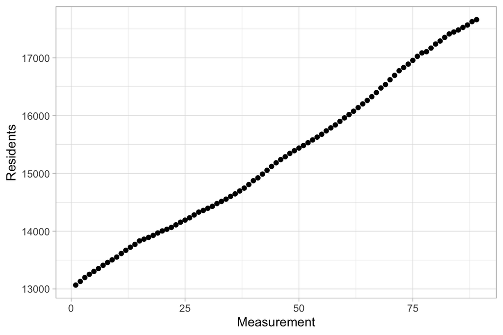

## Reduce number of datapoints

Let’s say, that instead of having four measures per year, we want 1 measure every 3 years.  
We can do this by making groups of 12 elements each with the `greedy` method and use the means of each group as our measurements.

When using the `greedy` method, we specify the desired group size. Every group, except the last, is guaranteed to have this size. The last group gets the elements that are left, i.e. it might be smaller or of the same size as the other groups.

```r
ts = timeSeriesFrame %>%

  # Group data
  group(n = 12, method = 'greedy') %>%

  # Find means of each group
  dplyr::summarise(mean = mean(residents))

# Show new data
ts %>% kable()
```

| .groups | mean |
| --- | --- |
| 1 | 13376.45 |
| 2 | 13945.62 |
| 3 | 14418.36 |
| 4 | 15022.52 |
| 5 | 15663.29 |
| 6 | 16378.30 |
| 7 | 17151.38 |
| 8 | 17573.18 |

A visualization of the data.

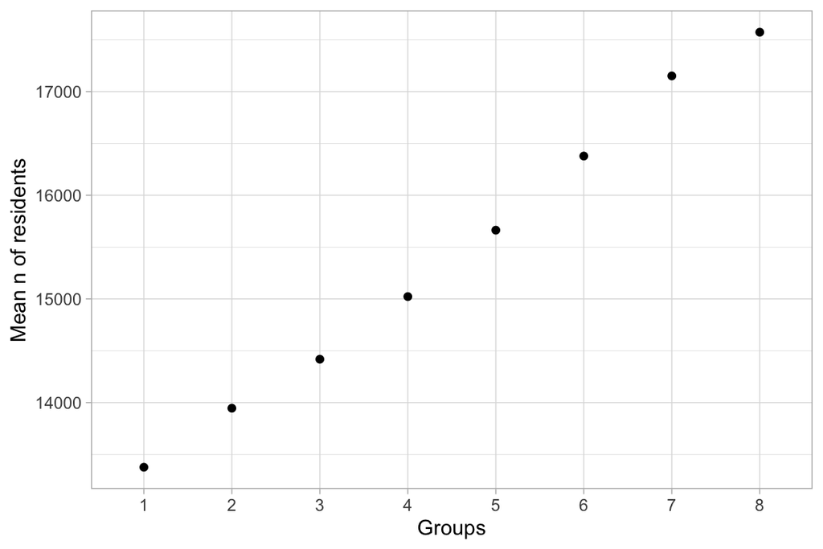

This procedure has left us with fewer datapoints, which could be useful if we had a very large `data frame` to start with, or if we just wanted to describe the change in residents every 3rd year (or every year for that matter, by simply changing `n` to `4`).

If we wanted to know which group had the largest increase in residents, we could find the range (difference between the max and min value) within each group instead of taking the mean.

```r
ts <- timeSeriesFrame %>%

  # Group data
  group(n = 12, method = 'greedy') %>%

  # Find range of each group
  dplyr::summarise(range = diff(range(residents)))

# Show new data
ts %>% kable()
```

| .groups | range |
| --- | --- |
| 1 | 602.2 |
| 2 | 433.0 |
| 3 | 454.2 |
| 4 | 650.8 |
| 5 | 568.0 |
| 6 | 758.9 |
| 7 | 614.2 |
| 8 | 178.9 |

## Staircase groups

For the fun of it, let’s say we want to make staircased groups inside the greedy groups, we just created.  
When using the `staircase` method we specify **step size**. Every group is 1 step larger than the previous group (e.g. with a step size of 5, group sizes would be 5,10,15,…).

By creating subgroups for every greedy group, the group size will “start over” for each greedy group.

When using the staircase method, the last group might not have the size of the second last group + step size. We want to make sure that it does have such size, so we use the helper tool `%staircase%` to find a step size with a remainder of 0.

```r
main_group_size = 12

# Loop through a list ranging from 1-30
for (step_size in c(1:30)){

  # If the remainder is 0
  if(main_group_size %staircase% step_size == 0){

    # Print the step size
    print(step_size)

  }

}
```

```
#> [1] 2
#> [1] 4
#> [1] 12
```

So our step size could be 2, 4 or 12. We pick a step size of 2, because it will yield the most subgroups for the example.

Now we will first make the greedy groups like before, then we will create subgroups with the staircase method.

In order not to overwrite the `.groups` column from the first use of `group()`, we will use the `col_name` argument in `group()`. As `group()` groups the `data frame` by the generated grouping factor (what a sentence!), a second call to it will create subgroups within the initial groups. Note that versions previous to `v1.3.0` did not detect these groupings, why you had to run the second `group()` call inside `dplyr`’s `do()` function.

```r
ts <- timeSeriesFrame %>%

  # Group data
  group(n = 12, method = 'greedy') %>%

  # Create subgroups
  group(n = 2, method = 'staircase', col_name = '.subgroups')
```

```
#> 'group()' now detects grouped data.frames and is applied group-wise (since v1.3.0). If this is unwanted, use 'dplyr::ungroup()' before 'group()'.
#> NOTE: This message is displayed once per session.
```

```r
# Show head of new data
ts %>% head(24) %>% kable()
```

| residents | .groups | .subgroups |
| --- | --- | --- |
| 13067.3 | 1 | 1 |
| 13130.5 | 1 | 1 |
| 13198.4 | 1 | 2 |
| 13254.2 | 1 | 2 |
| 13303.7 | 1 | 2 |
| 13353.9 | 1 | 2 |
| 13409.3 | 1 | 3 |
| 13459.2 | 1 | 3 |
| 13504.5 | 1 | 3 |
| 13552.6 | 1 | 3 |
| 13614.3 | 1 | 3 |
| 13669.5 | 1 | 3 |
| 13722.6 | 2 | 1 |
| 13772.1 | 2 | 1 |
| 13832.0 | 2 | 2 |
| 13862.6 | 2 | 2 |
| 13893.0 | 2 | 2 |
| 13926.8 | 2 | 2 |
| 13968.9 | 2 | 3 |
| 14004.7 | 2 | 3 |
| 14033.1 | 2 | 3 |
| 14066.0 | 2 | 3 |
| 14110.1 | 2 | 3 |
| 14155.6 | 2 | 3 |

We can get the means of each subgroup. To do this, we first group by `.groups` and then `.subgroups`. Then, we find the mean number of residents for each subgroup. If we had just grouped by `.subgroups`, we would have taken the mean of all the data points in each subgroup level. This would have left us with (in this case) 3 means, instead of 1 per subgroup level per main group level.

Now that we are at it, we might as well find the ranges for each subgroup as well.

```r
ts_means <- ts %>%

  # Group by first .groups, then .subgroups
  group_by(.groups, .subgroups) %>%

  # Find the mean and range of each subgroup
  dplyr::summarise(mean = mean(residents),
                   range = diff(range(residents)))
# Show head of new data
ts_means %>% head(9) %>% kable()
```

| .groups | .subgroups | mean | range |
| --- | --- | --- | --- |
| 1 | 1 | 13098.90 | 63.2 |
| 1 | 2 | 13277.55 | 155.5 |
| 1 | 3 | 13534.90 | 260.2 |
| 2 | 1 | 13747.35 | 49.5 |
| 2 | 2 | 13878.60 | 94.8 |
| 2 | 3 | 14056.40 | 186.7 |
| 3 | 1 | 14211.95 | 39.5 |
| 3 | 2 | 14341.92 | 115.1 |
| 3 | 3 | 14538.12 | 215.6 |

The differences in range follows the differences in number of measurements per subgroup.

Here is a visualization of the means per subgroup:

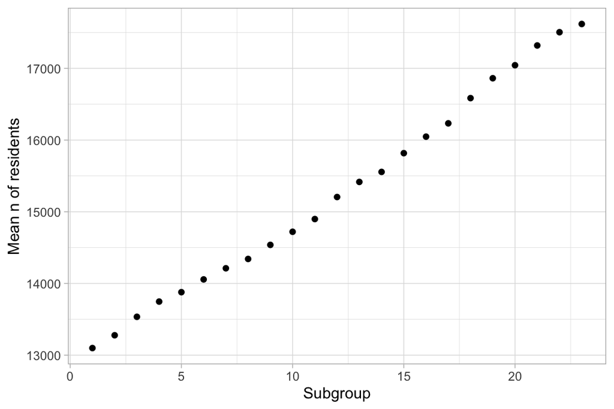

# Outro

Well done, you made it to the end of this introduction to `groupdata2`! If you want to know more about the various methods and arguments, you can read the Description of groupdata2.

If you have any questions or comments to this vignette (tutorial) or `groupdata2`, please send them to me at  
r-pkgs@ludvigolsen.dk, or open an issue on the github page https://github.com/LudvigOlsen/groupdata2 so I can make improvements.